# Analysis for San Francisco Bay Ford GoBike Service

## Introduction

> This data set includes information about individual rides made in a bike-sharing system covering the greater San Francisco Bay area.

The Data Each trip is anonymized and includes:

1. Trip Duration (seconds)
2. Start Time and Date
3. End Time and Date
4. Start Station ID
5. Start Station Name
6. Start Station Latitude
7. Start Station Longitude
8. End Station ID
9. End Station Name
10. End Station Latitude
11. End Station Longitude
12. Bike ID
13. User Type
14. Member Birth Year
15. Member Gender
16. Bike Share For All Trip

```
duration_sec                  0
start_time                    0
end_time                      0
start_station_id            197
start_station_name          197
start_station_latitude        0
start_station_longitude       0
end_station_id              197
end_station_name            197
end_station_latitude          0
end_station_longitude         0
bike_id                       0
user_type                     0
member_birth_year          8265
member_gender              8265
bike_share_for_all_trip       0
dtype: int64
```

### Question

- What is the gender distibution of Users?

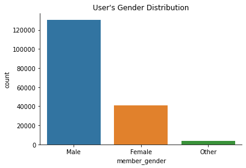

### Question

- What is the Average Bike Trip(Seconds)

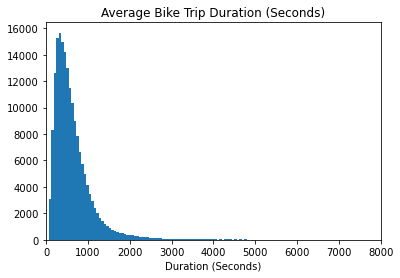

### Question

- What is the average bike trip (minutes)

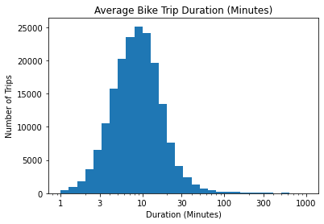

### Question

- What is the distribution of Users?

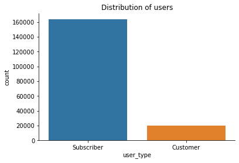

### Question

- Does a user share bike for all trips?

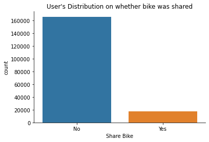

### Question

- What is the percentage of bike users?

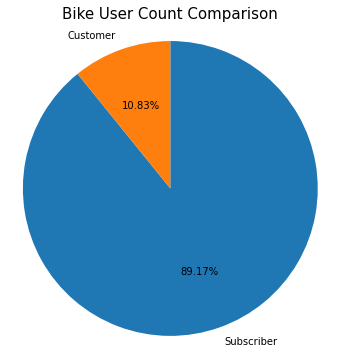

### Question

- What is the bike usage based on weekday?

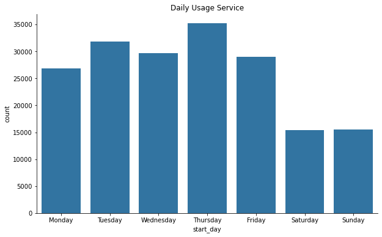

### Question

- What are the top 10 starting point for bike trips?

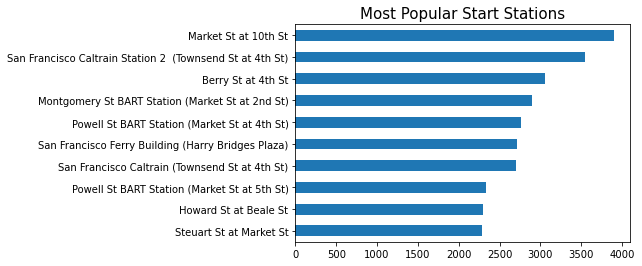

### Question

- What is the bike usage per day based on gender?

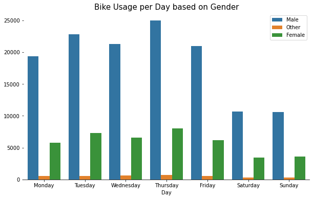

### Question

- What is the hourly usage of bikes per day based on user type?

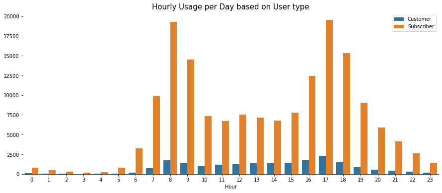

### Question

- What is the hourly usage of bike per day with respect to gender?

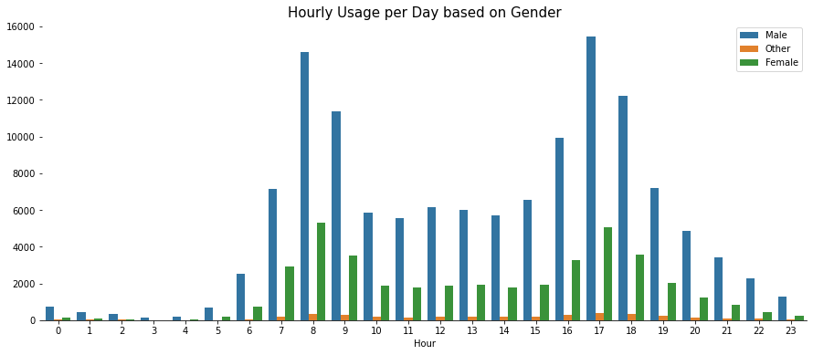

### Question

- What is the Hourly Duration Usage based on User type?

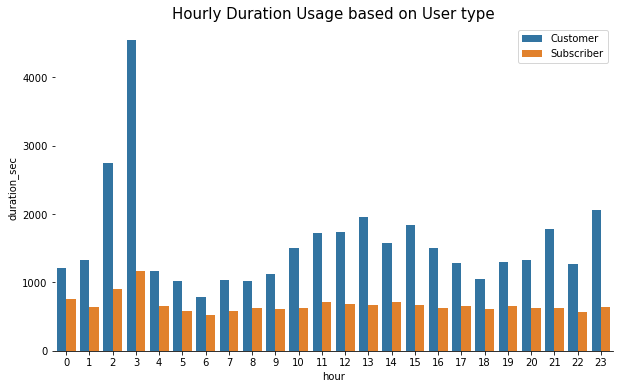

### Question

- What is the Hourly Duration Usage with respect to gender?

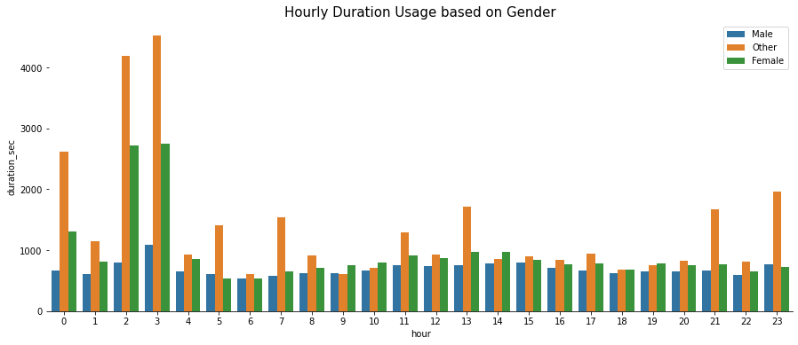